# Análisis de variables categóricas, clasificación y optimización con redes neuronales - préstamos en instituciones bancarias

### Formato a la variable de salida

```python
#Se modifica la variable de salida (de estudio): TIPOCLIENTE. Es mejor tener la salida en formato binario cuando hay dos clases
dataframe['Tumour Case'] = dataframe['Tumour Case'].replace(2, 0)
dataframe.head()
```

|  | Case Type | Tumour Case | Age of Mother | Age of Father | Age at First Diagnosis | Café au lait (CLS) | Axillary Freckles | Inguinal Freckles | Lisch Nodules | Dermal Neurofibromins | Plexiform Neurofibromins | Optic Glioma | Skeletal Dysplasia | Learning Disability | Hypertension | Astrocytoma | Hamartoma | Scoliosis | Other Symptoms | Diagnosis |
| --- | --- | --- | --- | --- | --- | --- | --- | --- | --- | --- | --- | --- | --- | --- | --- | --- | --- | --- | --- | --- |
| 0 | 0 | 1 | 30.0 | 31.0 | 5.0 | 0 | 0 | 0 | 0 | 0 | 0 | 1 | 0 | 0 | 0 | 0 | 0 | 0 | 1 | 1 |
| 1 | 0 | 1 | 22.0 | 29.0 | 7.0 | 1 | 1 | 0 | 0 | 1 | 0 | 0 | 0 | 0 | 0 | 0 | 0 | 0 | 1 | 1 |
| 2 | 1 | 1 | 28.0 | 26.0 | 9.0 | 1 | 1 | 0 | 0 | 1 | 0 | 0 | 1 | 0 | 0 | 0 | 0 | 0 | 1 | 1 |
| 3 | 0 | 1 | 30.0 | 34.0 | 9.0 | 1 | 1 | 0 | 1 | 0 | 1 | 0 | 0 | 0 | 0 | 0 | 0 | 0 | 1 | 1 |
| 4 | 0 | 1 | 27.0 | 34.0 | 1.0 | 1 | 1 | 1 | 0 | 0 | 0 | 1 | 0 | 0 | 0 | 0 | 0 | 0 | 1 | 1 |

En este paso se transforma la variable de salida Tumour Case para dejarla en formato binario, reemplazando el valor 2 por 0, lo cual es adecuado cuando el problema de clasificación tiene solo dos clases. Esta normalización facilita el entrenamiento de modelos de machine learning que trabajan mejor con salidas codificadas como 0 y 1. Tras la conversión, se muestran nuevamente las primeras filas del dataset para confirmar que la variable ha sido modificada correctamente.

### Eliminación de variables y separación de variable de salida

```python
#Se separa la variable de salida "Y" para poder realizar la preparación de datos a las variables independiente "X"
Y=dataframe['Tumour Case']
dataframe=dataframe.drop(['Plexiform Neurofibromins'], axis=1)
dataframe=dataframe.drop(['Dermal Neurofibromins'], axis=1)
dataframe=dataframe.drop(['Tumour Case'], axis=1)
print(dataframe.shape)
dataframe.head()
```

```
(258, 17)
```

|  | Case Type | Age of Mother | Age of Father | Age at First Diagnosis | Café au lait (CLS) | Axillary Freckles | Inguinal Freckles | Lisch Nodules | Optic Glioma | Skeletal Dysplasia | Learning Disability | Hypertension | Astrocytoma | Hamartoma | Scoliosis | Other Symptoms | Diagnosis |
| --- | --- | --- | --- | --- | --- | --- | --- | --- | --- | --- | --- | --- | --- | --- | --- | --- | --- |
| 0 | 0 | 30.0 | 31.0 | 5.0 | 0 | 0 | 0 | 0 | 1 | 0 | 0 | 0 | 0 | 0 | 0 | 1 | 1 |
| 1 | 0 | 22.0 | 29.0 | 7.0 | 1 | 1 | 0 | 0 | 0 | 0 | 0 | 0 | 0 | 0 | 0 | 1 | 1 |
| 2 | 1 | 28.0 | 26.0 | 9.0 | 1 | 1 | 0 | 0 | 0 | 1 | 0 | 0 | 0 | 0 | 0 | 1 | 1 |
| 3 | 0 | 30.0 | 34.0 | 9.0 | 1 | 1 | 0 | 1 | 0 | 0 | 0 | 0 | 0 | 0 | 0 | 1 | 1 |
| 4 | 0 | 27.0 | 34.0 | 1.0 | 1 | 1 | 1 | 0 | 1 | 0 | 0 | 0 | 0 | 0 | 0 | 1 | 1 |

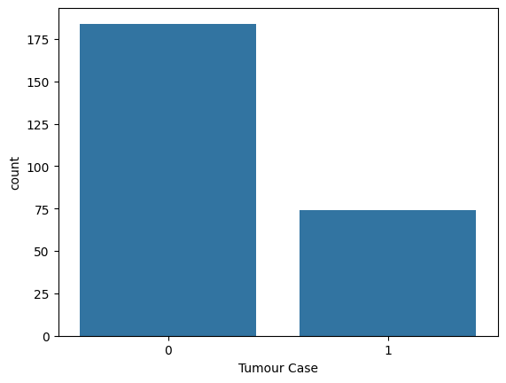

```python
#Se genera una figura de frecuencia de clase, es decir, la cantidad de muestras en cada clase.
sns.countplot(x=Y)
```

Se generó un gráfico de barras para visualizar la distribución de la variable de salida Tumour Case. En esta figura se observa un marcado desbalance en el número de muestras por clase: la clase 0 (casos sin tumor) presenta una frecuencia considerablemente mayor, mientras que la clase 1 (casos con tumor) contiene muchas menos observaciones. Esta diferencia implica un conjunto de datos desbalanceado, lo cual es importante considerar en las etapas de entrenamiento y evaluación del modelo.

### Análisis de variables categóricas

```python
# Variables binarias/categóricas
categorical_binary_features = [
    'Case Type',              # Sporadic / Familial
    'Café au lait (CLS)',
    'Axillary Freckles',
    'Inguinal Freckles',
    'Lisch Nodules',
    'Optic Glioma',
    'Skeletal Dysplasia',
    'Learning Disability',
    'Hypertension',
    'Astrocytoma',
    'Hamartoma',
    'Scoliosis',
    'Other Symptoms'
]

# Variables numéricas
numeric_features = [
    'Age of Mother',
    'Age of Father',
    'Age at First Diagnosis'
]

# Verificación de que todas las columnas existan
for col in categorical_binary_features + numeric_features:
    if col not in dataframe.columns:
        raise ValueError(f"La columna '{col}' no existe en el DataFrame. Revisa el nombre exacto.")

print("Todas las columnas están correctas y coinciden con el DataFrame.")
```

```
Todas las columnas están correctas y coinciden con el DataFrame.
```

Se clasifican las variables del dataset según su tipo: por un lado, se agrupan las características binarias o categóricas que representan la presencia o ausencia de síntomas, y por otro lado se identifican las variables numéricas relacionadas con edades. Luego, se realiza una verificación automática para asegurarse de que cada nombre de columna especificado coincida realmente con el DataFrame, evitando errores en etapas posteriores de preprocesamiento. Al finalizar, se confirma que todas las columnas han sido identificadas correctamente.

```python
def analisisVariables(dataframe, categorical_binary_features, numeric_features):


    # Total de variables después de eliminar columnas
    cantidadTotalVariables = len(dataframe.columns)
    print('Cantidad de variables después de eliminar columnas no deseadas: ', cantidadTotalVariables)

    # Cantidad de variables binarias
    cantidadVariablesBinarias = len(categorical_binary_features)

    # Revisar categorías en variables binarias (aunque deberían ser 2, lo dejamos general)
    for variable in categorical_binary_features:
        if variable in dataframe.columns:
            cantidadCategorias = dataframe[variable].nunique()
            print(f'Cantidad de categorías en la variable {variable}: {cantidadCategorias}')

    # Cantidad total de variables considerando transformación (solo se suman variables binarias)
    cantidadTotalVariablesConTransformacion = cantidadTotalVariables  # en este dataset las binarias ya son binarias
    print('Cantidad total de variables considerando transformación: ', cantidadTotalVariablesConTransformacion)

    return cantidadTotalVariablesConTransformacion
```

La función analisisVariables realiza un resumen estructurado de las características del dataset después del preprocesamiento. Primero muestra cuántas variables permanecen en el DataFrame, luego analiza cada variable binaria verificando cuántas categorías distintas contiene, lo cual es útil para confirmar que realmente representan valores binarios. Finalmente, devuelve la cantidad total de variables que se utilizarán en el modelo, considerando que en este caso no se requiere transformar las variables binarias.

```python
cantidadTotalVariablesConTransformacion=analisisVariables(dataframe, categorical_binary_features, numeric_features)
print('Cantidad de variables que habrá después de la transformación de variables: ',cantidadTotalVariablesConTransformacion)
```

```
Cantidad de variables después de eliminar columnas no deseadas:  17
Cantidad de categorías en la variable Case Type: 2
Cantidad de categorías en la variable Café au lait (CLS): 2
Cantidad de categorías en la variable Axillary Freckles: 2
Cantidad de categorías en la variable Inguinal Freckles: 2
Cantidad de categorías en la variable Lisch Nodules: 2
Cantidad de categorías en la variable Optic Glioma: 2
Cantidad de categorías en la variable Skeletal Dysplasia: 2
Cantidad de categorías en la variable Learning Disability: 2
Cantidad de categorías en la variable Hypertension: 2
Cantidad de categorías en la variable Astrocytoma: 2
Cantidad de categorías en la variable Hamartoma: 2
Cantidad de categorías en la variable Scoliosis: 2
Cantidad de categorías en la variable Other Symptoms: 2
Cantidad total de variables considerando transformación:  17
Cantidad de variables que habrá después de la transformación de variables:  17
```

Existen 13 variables categóricas binarias, todas ellas ya codificadas con dos categorías (0/1), por lo que no generan nuevas variables al transformarlas. Además, existen 3 variables numéricas, que tampoco cambian su estructura. En total, el dataframe contiene 17 variables después de eliminar columnas que no se utilizan.

Cada una de las 13 variables categóricas presenta exactamente 2 categorías, por lo que no se requiere crear variables dummy adicionales, ya que ya están en formato binario. Por lo tanto, el número total de variables después de la transformación sigue siendo exactamente el mismo: 17 variables.

Como en este dataset no existen variables categóricas nominales multiclase que deban convertirse en múltiples variables binarias, no se agregan nuevas columnas ni se reemplaza ninguna variable, por lo que:

**Variables finales=17**

El dataframe luego de la transformación categórica a numérica tendrá 17 variables.

### Diseño de transformadores

Por medio de un Pipeline creamos un estimador compuesto. Esta herramienta nos permite combinar preprocesadores y transformadores para llevar un orden y estructura en el proceso de transformación de variables. Para una mejor organización creamos los preprocesadores y sus métodos de transformación.

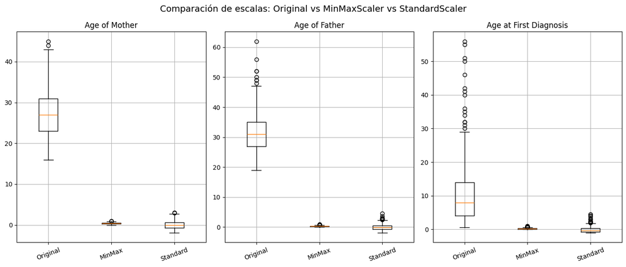

```python
# -------------------------------------------------------------
# TUS PREPROCESADORES (código original)
# -------------------------------------------------------------
preprocesorBinarioNumerico = ColumnTransformer(
    transformers=[
        ('num', 'passthrough', numeric_features),  # las numéricas se procesarán luego
        ('bin', 'passthrough', categorical_binary_features)   # binarias se dejan tal cual
    ],
    remainder='drop',
    n_jobs=-1
)

# ---- 2. Normalización con MinMaxScaler ----
minmax_transformer = Pipeline(steps=[
    ('minmax', MinMaxScaler(feature_range=(0, 1)))
])
preprocesorMinMax = ColumnTransformer(
    transformers=[
        ('scaler', minmax_transformer, numeric_features)
    ],
    remainder='passthrough'
)

# ---- 3. Estandarización con StandardScaler ----
standardscaler_transformer = Pipeline(steps=[
    ('scaler', StandardScaler(with_mean=True, with_std=True))
])
preprocesorStandardScaler = ColumnTransformer(
    transformers=[
        ('scaler', standardscaler_transformer, numeric_features)
    ],
    remainder='passthrough'
)

# ---- 4. Imputación Simple ----
simpleimputer_transformer = Pipeline(steps=[
    ('simpleimputer', SimpleImputer(strategy='median'))
])
preprocesorSimpleImputer = ColumnTransformer(
    transformers=[
        ('imputer', simpleimputer_transformer, numeric_features)
    ],
    remainder='passthrough'
)

# ---- 5. Pipeline final ----
pipe = Pipeline(steps=[
    ('preproc_bin_num', preprocesorBinarioNumerico),
    ('imputer', preprocesorSimpleImputer),
    ('scaler_std', preprocesorStandardScaler)  # o preprocesorMinMax
])

# -------------------------------------------------------------
# 🔥 GRÁFICAS COMPARATIVAS DE ESCALA
# -------------------------------------------------------------
import matplotlib.pyplot as plt
import pandas as pd

# 1. Extraer datos originales numéricos
X_original = dataframe[numeric_features]

# 2. MinMaxScaler
X_minmax = preprocesorMinMax.fit_transform(dataframe[numeric_features])
X_minmax = pd.DataFrame(X_minmax, columns=numeric_features)

# 3. StandardScaler
X_standard = preprocesorStandardScaler.fit_transform(dataframe[numeric_features])
X_standard = pd.DataFrame(X_standard, columns=numeric_features)

# -------------------------------------------
# 🚀 Graficar cada variable numérica
# -------------------------------------------
plt.figure(figsize=(14, 6))

for i, col in enumerate(numeric_features):
    plt.subplot(1, len(numeric_features), i+1)
    plt.boxplot(
        [X_original[col], X_minmax[col], X_standard[col]],
        labels=["Original", "MinMax", "Standard"]
    )
    plt.title(col)
    plt.xticks(rotation=20)
    plt.grid(True)

plt.suptitle("Comparación de escalas: Original vs MinMaxScaler vs StandardScaler", fontsize=14)
plt.tight_layout()
plt.show()
```

La gráfica compara cómo cambian las variables numéricas del dataset NF4 al aplicar tres métodos de preprocesamiento: valores originales, MinMaxScaler y StandardScaler. Se observa el reescalado al rango [0,1] con MinMax y la normalización alrededor de cero con StandardScaler, lo que permite identificar la dispersión, outliers y el impacto de cada técnica en los datos

### Diseño de pipeline

El procesador 'prepcn' es indispensable que se aplique antes de los demás preprocesadores numéricos. En el Pipeline "pipe" se aplica primeramente la tansformación de variables categóricas a variables numéricas y en segundo lugar se aplica la transformación numérica.

```python
# Definir función para crear el modelo (fuera de cualquier otra función)
def crear_modelo_nn():
    model = Sequential()
    model.add(Dense(16, input_dim=16, activation='relu'))  # <- input_dim=16
    model.add(Dense(1, activation='sigmoid'))
    model.compile(optimizer='adam', loss='binary_crossentropy', metrics=['accuracy'])
    return model

modeloNN = KerasClassifier(build_fn=crear_modelo_nn, epochs=200, batch_size=5, verbose=2)
```

```python
pipe = Pipeline(steps=[
    ('prepcn', preprocesorBinarioNumerico),
    ('prepstandard', preprocesorStandardScaler),
    ('modelNN', modeloNN)
])
```

Se define una función que crea una red neuronal simple con una capa oculta de 16 neuronas y una capa de salida sigmoidal para clasificación binaria; luego envuelve ese modelo en KerasClassifier y construye un pipeline donde primero se seleccionan y procesan las variables (binarias y numéricas), después se estandarizan y finalmente se entrena la red neuronal, permitiendo ejecutar todo el flujo —preprocesamiento + modelo— con una sola llamada.

### Transformación de variables

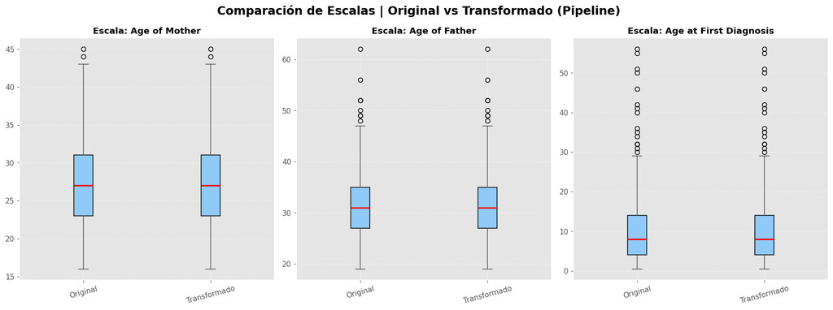

```python
import pandas as pd
import matplotlib.pyplot as plt

# ---- Separar columnas predictoras y objetivo ----
X = dataframe[categorical_binary_features + numeric_features]
Y = dataframe['Diagnosis']

# ---- Aplicar solo el preprocesamiento del pipeline ----
X_Transformado = pipe.named_steps['prepcn'].fit_transform(X)

# ---- Obtener nombres de columnas transformadas ----
transformed_columns = []
for name, transformer, cols in pipe.named_steps['prepcn'].transformers_:
    if hasattr(transformer, 'get_feature_names_out'):
        names = transformer.get_feature_names_out(cols)
        transformed_columns.extend(names)
    else:
        transformed_columns.extend(cols)

# ---- Crear DataFrame transformado ----
X_Transformado_df = pd.DataFrame(X_Transformado, columns=transformed_columns)

# ---- Agregar variable objetivo ----
X_Transformado_df['Diagnosis'] = Y.reset_index(drop=True)

# ---- Guardar CSV ----
X_Transformado_df.to_csv("DatasetTransformadoConEtiquetas.csv", sep=";", index=False)

# -------------------------------------------------------------------
# 🔥 GRÁFICA COMPARATIVA MEJORADA: ORIGINAL vs TRANSFORMADO
# -------------------------------------------------------------------

plt.style.use("ggplot")   # estilo visual moderno

fig, axes = plt.subplots(
    nrows=1,
    ncols=len(numeric_features),
    figsize=(16, 6),
    dpi=110
)

if len(numeric_features) == 1:
    axes = [axes]  # cuando es solo un feature

for ax, col in zip(axes, numeric_features):
    ax.boxplot(
        [X[col], X_Transformado_df[col]],
        labels=["Original", "Transformado"],
        patch_artist=True,
        boxprops=dict(facecolor="#90CAF9"),
        medianprops=dict(color="red", linewidth=2),
        whiskerprops=dict(color="#555"),
        capprops=dict(color="#555")
    )
    ax.set_title(f"Escala: {col}", fontsize=12, fontweight="bold")
    ax.set_xticklabels(["Original", "Transformado"], rotation=15)
    ax.grid(True, linestyle="--", alpha=0.5)

fig.suptitle(" Comparación de Escalas | Original vs Transformado (Pipeline)", fontsize=16, fontweight="bold")
plt.tight_layout()
plt.show()
```

El dataset original, separa las variables predictoras y la variable objetivo, aplica únicamente el paso de preprocesamiento del pipeline para transformar X, reconstruye un DataFrame con los nombres reales de las columnas resultantes del ColumnTransformer, agrega nuevamente la columna objetivo y finalmente guarda el dataset ya transformado y listo para modelar en un archivo CSV.

```python
# Funciones para guardar y cargar un Pipeline o Modelo
def guardarPipeline(pipeline,nombreArchivo):
    with open(nombreArchivo+'.pickle', 'wb') as handle:
        pickle.dump(pipeline, handle, protocol=pickle.HIGHEST_PROTOCOL)
```

```python
from google.colab import drive
drive.mount('/content/drive')

nombreArchivoPreprocesador='/content/drive/My Drive/PrácticasRedesNeuronales/pipePreprocesadores'
guardarPipeline(pipe,nombreArchivoPreprocesador)
```

## Fase 2: Entrenamiento base de una red neuronal

### Carga de pipeline de preparación del conjunto de datos

Se puede cargar un Pipeline creado previamente para la preparación de los datos de este dataset.

```python
from google.colab import drive
drive.mount('/content/drive')
```

```python
def cargarPipeline(nombreArchivo):
    with open(nombreArchivo+'.pickle', 'rb') as handle:
        pipeline = pickle.load(handle)
    return pipeline
```

```python
from sklearn.pipeline import Pipeline
from sklearn import set_config
import pickle
import os

# ---- Cargar pipeline ----
nombreArchivoPreprocesador = '/content/drive/MyDrive/PrácticasRedesNeuronales/pipePreprocesadores.pickle'

def cargarPipeline(nombreArchivo):
    if not os.path.exists(nombreArchivo):
        raise FileNotFoundError(f"No se encontró el archivo: {nombreArchivo}")
    with open(nombreArchivo, 'rb') as handle:
        pipeline = pickle.load(handle)
    return pipeline

pipe = cargarPipeline(nombreArchivoPreprocesador)

# ---- Crear pipeline temporal solo con transformadores ----
pasos_transformadores = [(nombre, paso) for nombre, paso in pipe.steps if nombre != 'modelNN']
pipe_diagrama = Pipeline(steps=pasos_transformadores)

# ---- Imprimir cantidad de pasos ----
print("Cantidad de pasos en el pipeline (solo transformadores):", len(pipe_diagrama.steps))

# ---- Activar diagrama ----
set_config(display='diagram')

# ---- Mostrar pipeline en diagrama ----
pipe_diagrama
```

```
Cantidad de pasos en el pipeline (solo transformadores): 2
```

```
Pipeline(steps=[('prepcn',
                 ColumnTransformer(n_jobs=-1,
                                   transformers=[('num', 'passthrough',
                                                  ['Age of Mother',
                                                   'Age of Father',
                                                   'Age at First Diagnosis']),
                                                 ('bin', 'passthrough',
                                                  ['Case Type',
                                                   'Café au lait (CLS)',
                                                   'Axillary Freckles',
                                                   'Inguinal Freckles',
                                                   'Lisch Nodules',
                                                   'Optic Glioma',
                                                   'Skeletal Dysplasia',
                                                   'Learning Disability',
                                                   'Hypertension',
                                                   'Astrocytoma', 'Hamartoma',
                                                   'Scoliosis',
                                                   'Other Symptoms'])])),
                ('prepstandard',
                 ColumnTransformer(remainder='passthrough',
                                   transformers=[('scaler',
                                                  Pipeline(steps=[('scaler',
                                                                   StandardScaler())]),
                                                  ['Age of Mother',
                                                   'Age of Father',
                                                   'Age at First '
                                                   'Diagnosis'])]))])
```

Se carga desde disco un pipeline previamente guardado con pickle, luego crea una copia del pipeline que contiene solo los pasos de preprocesamiento (excluyendo el modelo neuronal), y finalmente usa set_config(display='diagram') para mostrar un diagrama visual del flujo de transformación. El diagrama resultante muestra dos pasos principales:

- prepcn → un ColumnTransformer que deja pasar tus variables numéricas y binarias sin modificarlas.
- prepstandard → otro ColumnTransformer que aplica StandardScaler solo a las variables numéricas, dejando todas las demás columnas tal como están (passthrough).

El pipeline cargado preprocesa tus datos pasando primero todas las variables sin cambios y luego estandariza únicamente las columnas numéricas antes de alimentar el modelo original.

```python
#Funciones para guardar y cargar la Red Neuronal (Arquitectura y Pesos)
def guardarNN(model,nombreArchivo):
    print("Guardando Red Neuronal en Archivo")
    model.save(nombreArchivo+'.h5')
    print("Red Neuronal Grabada en Archivo")

def cargarNN(nombreArchivo):
    model = load_model(nombreArchivo+'.h5')
    print("Red Neuronal Cargada desde Archivo")
    return model
```

**Parámetros principales de la Red Neuronal utilizada**

En el modelo construido con Keras, los parámetros fundamentales fueron los siguientes: epochs, que indican cuántas veces se repite el proceso completo de forward y backpropagation; batch_size, que determina cuántas muestras se utilizan en cada actualización de pesos; y el optimizer, que en mi caso fue Adam, el cual es un algoritmo de descenso del gradiente encargado de ajustar los pesos de la red durante el entrenamiento.

**Modificación del Pipeline utilizado**

### Creación de la Red Neuronal

A continuación, creamos la Red Neuronal. Luego, agregamos el clasificador al final del Pipeline.

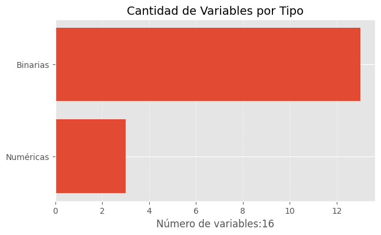

```python
import matplotlib.pyplot as plt

num_count = len(numeric_features)
bin_count = len(categorical_binary_features)

plt.figure(figsize=(7,4))
plt.barh(["Numéricas", "Binarias"], [num_count, bin_count])
plt.title("Cantidad de Variables por Tipo", fontsize=14)
plt.xlabel("Número de variables:16")
plt.grid(axis='x', linestyle='--', alpha=0.5)
plt.show()
```

```python
model = Sequential()

#La primera capa Dense recibe el numero de variables, que es la segunda dimensión del dataframe
#La primera capa tiene 3 neuronas. La función de activación es la función rectificadora.
model.add(Dense(512, input_shape=(cantidadVariablesIndependientes,), activation='relu'))
#La capa de salida tiene 1 neurona. La capa de salida debe tener la misma dimensión como de cantidad de salidas queremos,
#por ejemplo, en este caso la salida "TIPOCLIENTE" solo requiere un valor: 0 o 1, entonces 1 neurona es suficiente.
#La función de activación es sigmoid para calcular la clasificación en términos de probabilidad.
model.add(Dense(512, activation='sigmoid'))
model.add(Dense(512, activation='sigmoid'))
model.add(Dense(512, activation='sigmoid'))

model.add(Dense(512, activation='sigmoid'))
model.add(Dense(512, activation='sigmoid'))
model.add(Dense(512, activation='sigmoid'))

model.add(Dense(512, activation='sigmoid'))
model.add(Dense(512, activation='sigmoid'))
model.add(Dense(512, activation='sigmoid'))

model.add(Dense(512, activation='sigmoid'))
model.add(Dense(512, activation='sigmoid'))
model.add(Dense(512, activation='sigmoid'))

model.add(Dense(1, activation='sigmoid'))

#Como tenemos dos posibles valores de salida "0 o 1", vamos a escoger que el error lo trate como una clasificación binaria.
model.compile(loss='binary_crossentropy', optimizer='rmsprop', metrics=['acc'])

#Se inserta el modelo como paso final del pipeline
pipe.steps.append(['modelNN',model])
#Aquí en lugar del clasificador de Red Neuronal podría ser otro modelo como un Random Forest, una SVM, etc.

#También se pudo haber insertado el modelo indicando el índice (el número de paso específico dentro del pipeline)
#pipe.steps.insert(cantidadPasos,['modelNN',model])

#Se puede eliminar un paso específico del pipeline de la siguiente manera
#pipe.steps.pop()

print("Cantidad de pasos: ",len(pipe.steps))

#Mostrar el resumen de la arquitectura de la red neuronal.
pipe.named_steps['modelNN'].summary()
```

```
Cantidad de pasos:  4
```

```
Model: "sequential"
```

```
┏━━━━━━━━━━━━━━━━━━━━━━━━━━━━━━━━━┳━━━━━━━━━━━━━━━━━━━━━━━━┳━━━━━━━━━━━━━━━┓
┃ Layer (type)                    ┃ Output Shape           ┃       Param # ┃
┡━━━━━━━━━━━━━━━━━━━━━━━━━━━━━━━━━╇━━━━━━━━━━━━━━━━━━━━━━━━╇━━━━━━━━━━━━━━━┩
│ dense (Dense)                   │ (None, 512)            │         8,704 │
├─────────────────────────────────┼────────────────────────┼───────────────┤
│ dense_1 (Dense)                 │ (None, 512)            │       262,656 │
├─────────────────────────────────┼────────────────────────┼───────────────┤
│ dense_2 (Dense)                 │ (None, 512)            │       262,656 │
├─────────────────────────────────┼────────────────────────┼───────────────┤
│ dense_3 (Dense)                 │ (None, 512)            │       262,656 │
├─────────────────────────────────┼────────────────────────┼───────────────┤
│ dense_4 (Dense)                 │ (None, 512)            │       262,656 │
├─────────────────────────────────┼────────────────────────┼───────────────┤
│ dense_5 (Dense)                 │ (None, 512)            │       262,656 │
├─────────────────────────────────┼────────────────────────┼───────────────┤
│ dense_6 (Dense)                 │ (None, 512)            │       262,656 │
├─────────────────────────────────┼────────────────────────┼───────────────┤
│ dense_7 (Dense)                 │ (None, 512)            │       262,656 │
├─────────────────────────────────┼────────────────────────┼───────────────┤
│ dense_8 (Dense)                 │ (None, 512)            │       262,656 │
├─────────────────────────────────┼────────────────────────┼───────────────┤
│ dense_9 (Dense)                 │ (None, 512)            │       262,656 │
├─────────────────────────────────┼────────────────────────┼───────────────┤
│ dense_10 (Dense)                │ (None, 512)            │       262,656 │
├─────────────────────────────────┼────────────────────────┼───────────────┤
│ dense_11 (Dense)                │ (None, 512)            │       262,656 │
├─────────────────────────────────┼────────────────────────┼───────────────┤
│ dense_12 (Dense)                │ (None, 512)            │       262,656 │
├─────────────────────────────────┼────────────────────────┼───────────────┤
│ dense_13 (Dense)                │ (None, 1)              │           513 │
└─────────────────────────────────┴────────────────────────┴───────────────┘
```

```
 Total params: 3,161,089 (12.06 MB)
```

```
 Trainable params: 3,161,089 (12.06 MB)
```

```
 Non-trainable params: 0 (0.00 B)
```

```python
print("Cantidad de pasos: ",len(pipe.steps))
pipe.steps.pop()
print("Cantidad de pasos: ",len(pipe.steps))
```

```
Cantidad de pasos:  4
Cantidad de pasos:  3
```

En esta red neuronal, el valor **Param #** indica cuántos parámetros (pesos + bias) necesita cada capa para funcionar. En una capa densa, los parámetros se calculan como:

**(número de entradas × número de neuronas) + (número de neuronas).**

Por ejemplo, la primera capa recibe cantidadVariablesIndependientes entradas y tiene 512 neuronas, por lo que requiere (cantidadVariablesIndependientes × 512) + 512 parámetros; dado que el resumen muestra **8.704 parámetros**, esto implica que el modelo está utilizando **16 variables independientes** **(16×512) + 512=8.704**. Cada capa oculta posterior también tiene 512 entradas y 512 neuronas, así que cada una requiere **(512×512) + 512 = 262.656 parámetros**, lo cual coincide con lo mostrado para todas las capas ocultas del modelo. Finalmente, la capa de salida tiene 512 entradas y 1 neurona, por lo que requiere **(512×1) + 1 = 513 parámetros**. Sumando todas las capas, la red completa utiliza 3.161.089 parámetros, que corresponden a los pesos y biases necesarios para entrenar un modelo profundo con múltiples capas densamente conectadas.

### Entrenamiento de la Red Neuronal

Para el entrenamiento y testing del modelo se genera las particiones del conjunto de datos en X_train, X_test, y_train, y_test. Convencionalmente, el 80% es para entrenamiento y el 20% es para testing. Más adelante veremos que parte del conjunto de entrenamiento se puede separar para validación (ajuste/optimización de hiperparámetros del modelo).

```python
import copy
from sklearn.model_selection import train_test_split
import pickle
import os
from sklearn.pipeline import Pipeline

# --- Reload the pipeline to ensure it's in a clean state ---
def cargarPipeline(nombreArchivo):
    if not os.path.exists(nombreArchivo):
        raise FileNotFoundError(f"No se encontró el archivo: {nombreArchivo}")
    with open(nombreArchivo, 'rb') as handle:
        pipeline = pickle.load(handle)
    return pipeline

nombreArchivoPreprocesador = '/content/drive/MyDrive/PrácticasRedesNeuronales/pipePreprocesadores.pickle'
pipe = cargarPipeline(nombreArchivoPreprocesador)

# --- Define nombrePrep for this cell's context ---
nombrePrep = 'prepstandard'

# --- Prepare X_train for this cell's context ---
# Assuming 'dataframe', 'categorical_binary_features', 'numeric_features' are globally available.
X = dataframe[categorical_binary_features + numeric_features].copy()
Yval = dataframe['Diagnosis'].values # Assuming 'Diagnosis' is the target variable
X_train, _, _, _ = train_test_split(X, Yval, test_size=0.2, random_state=0)

# --- Apply preprocessing and get the input dimension ---
X_train_trans = pipe.named_steps[nombrePrep].fit_transform(X_train)
cantidadVariablesIndependientes = X_train_trans.shape[1]
print("Número de variables de entrada a la red neuronal:", cantidadVariablesIndependientes)
```

```
Número de variables de entrada a la red neuronal: 16
```

Se carga un pipeline previamente guardado y se utiliza para preparar los datos que serán la entrada de la red neuronal; para ello, primero se seleccionan las variables independientes del dataframe, agrupando las características categóricas binarias y las numéricas, y luego se separan en conjuntos de entrenamiento y prueba. El paso del pipeline llamado 'prepstandard' se aplica únicamente a los datos de entrenamiento, generando una matriz transformada cuyo número de columnas corresponde exactamente a la cantidad de variables que la red neuronal debe recibir como entrada. Finalmente, el valor cantidadVariablesIndependientes = X_train_trans.shape[1] obtiene este número de características transformadas, permitiendo definir correctamente la dimensión de entrada en la primera capa de la red neuronal.

```python
from sklearn.preprocessing import StandardScaler
from sklearn.compose import ColumnTransformer

# --- Preprocesamiento ---
numeric_features = ['Age of Mother', 'Age of Father', 'Age at First Diagnosis']
categorical_features = categorical_binary_features  # ya definida

preprocessor = ColumnTransformer(
    transformers=[
        ('num', StandardScaler(), numeric_features),
        ('cat', 'passthrough', categorical_features)
    ]
)
```

```python
import copy
from sklearn.model_selection import train_test_split
from sklearn.pipeline import Pipeline
import tensorflow as tf
from keras.models import Sequential
from keras.layers import Dense
from scikeras.wrappers import KerasClassifier

# ---- Datos ----
X = copy.deepcopy(dataframe[categorical_binary_features + numeric_features])
Yval = Y.values

# ---- Dividir train/test ----
X_train, X_test, y_train, y_test = train_test_split(X, Yval, test_size=0.2, random_state=0)

# --- Define the Keras model build function with tf.keras.Input to avoid warnings ---
# 'cantidadVariablesIndependientes' is assumed to be globally available from cell H1WGnEj1i8O- (value is 16)
def build_model_for_training(input_dim_val):
    model = Sequential()
    model.add(tf.keras.Input(shape=(input_dim_val,))) # Use Input layer to avoid warning
    model.add(Dense(3, activation='relu'))
    model.add(Dense(1, activation='sigmoid'))
    model.compile(loss='binary_crossentropy', optimizer='rmsprop', metrics=['accuracy'])
    return model

# --- Create a new KerasClassifier instance using the 'model' argument ---
# This replaces the old build_fn based KerasClassifier and removes the warning
estimator_for_training = KerasClassifier(
    model=lambda: build_model_for_training(input_dim_val=cantidadVariablesIndependientes), # Use 'model' argument
    epochs=10,
    batch_size=50,
    verbose=0
)

# --- Reconstruct the pipeline with the global 'preprocessor' and the new KerasClassifier ---
# 'preprocessor' (the combined ColumnTransformer) is assumed to be globally available from cell 89GTTNABm_jn.
pipe = Pipeline(steps=[
    ('preprocessor', preprocessor),
    ('modelNN', estimator_for_training)
])

# ---- Entrenar KerasClassifier ----
# The pipeline will now handle preprocessing (from 'preprocessor') and then train 'modelNN'.
pipe.fit(X_train, y_train)

print("Modelo base entrenado")
```

```
Modelo base entrenado
```

Se construye un pipeline que combina el preprocesamiento y el entrenamiento de una red neuronal; primero, el ColumnTransformer estandariza las variables numéricas mediante StandardScaler y deja pasar directamente las variables categóricas binarias, generando así el conjunto final de características que la red neuronal utilizará como entrada. Luego, después de dividir los datos en entrenamiento y prueba, se define una función que construye el modelo en Keras usando una capa de entrada basada en cantidadVariablesIndependientes, seguida de una capa oculta de 3 neuronas con activación relu y una capa de salida con activación sigmoid para clasificación binaria. Este modelo se integra en un KerasClassifier, configurado con 10 epochs y un batch de 50 muestras, y finalmente se arma un pipeline con dos pasos: el preprocesador y el modelo neuronal. Al ejecutar pipe.fit(X_train, y_train), el pipeline aplica el preprocesamiento y entrena automáticamente la red neuronal sobre los datos ya transformados, completando así el modelo base entrenado.

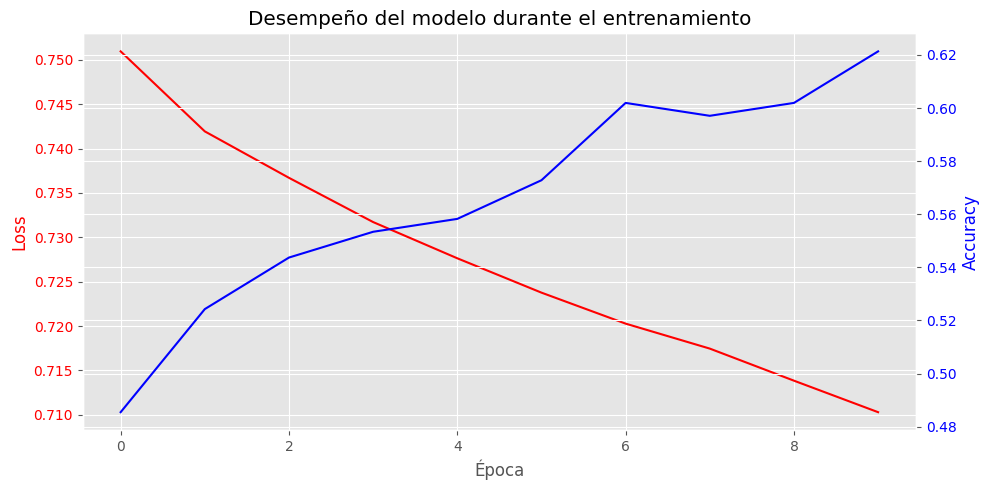

```python
import matplotlib.pyplot as plt

# ---- Acceder al historial de entrenamiento ----
history = pipe.named_steps['modelNN'].history_

# ---- Graficar pérdida (loss) y exactitud (accuracy) ----
fig, ax1 = plt.subplots(figsize=(10, 5))

# Pérdida
ax1.plot(history['loss'], 'r-', label='Loss')
ax1.set_xlabel('Época')
ax1.set_ylabel('Loss', color='r')
ax1.tick_params(axis='y', labelcolor='r')

# Exactitud en otro eje y
ax2 = ax1.twinx()
ax2.plot(history['accuracy'], 'b-', label='Accuracy')
ax2.set_ylabel('Accuracy', color='b')
ax2.tick_params(axis='y', labelcolor='b')

# Título y leyenda
plt.title('Desempeño del modelo durante el entrenamiento')
fig.tight_layout()
plt.show()
```

```python
guardarNN(model,'modeloRedNeuronalBase')
print('Modelo Base Guardado')
```

```
WARNING:absl:You are saving your model as an HDF5 file via `model.save()` or `keras.saving.save_model(model)`. This file format is considered legacy. We recommend using instead the native Keras format, e.g. `model.save('my_model.keras')` or `keras.saving.save_model(model, 'my_model.keras')`.
```

```
Guardando Red Neuronal en Archivo
Red Neuronal Grabada en Archivo
Modelo Base Guardado
```

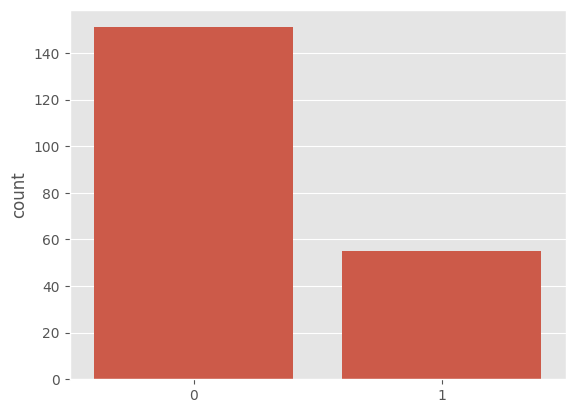

```python
sns.countplot(x=y_train)
```

La gráfica de barras generada con sns.countplot muestra la distribución de las clases en el conjunto de entrenamiento (y_train), evidenciando un desbalance importante entre las dos categorías: la clase 0 presenta una cantidad significativamente mayor de muestras (aprox. 150 casos), mientras que la clase 1 tiene muchas menos observaciones (aprox. 55 casos). Esta diferencia implica que el modelo de clasificación —en este caso, la red neuronal— podría tender a predecir con mayor frecuencia la clase dominante, por lo que será necesario considerar técnicas como class_weight, sobremuestreo o submuestreo para evitar que el desbalance afecte el rendimiento del modelo.

### Predicción con modelo base y evaluación de calidad: MAE, MSE, RMSE, Accuracy, Precision, Recall y F1

```python
X_test_trans = pipe.named_steps['preprocessor'].transform(X_test)
y_pred = pipe.named_steps['modelNN'].predict(X_test_trans)
y_pred = (y_pred > 0.5).astype("int32").flatten()
```

```python
dataframeFinal=pd.DataFrame({'real':y_test, 'predicción': y_pred})

np.set_printoptions(formatter={'float': lambda X: "{0:0.0f}".format(X)})

dataframeFinal.head(20)
```

|  | real | predicción |
| --- | --- | --- |
| 0 | 1 | 1 |
| 1 | 0 | 1 |
| 2 | 0 | 0 |
| 3 | 0 | 0 |
| 4 | 0 | 0 |
| 5 | 1 | 1 |
| 6 | 1 | 1 |
| 7 | 0 | 0 |
| 8 | 0 | 0 |
| 9 | 0 | 0 |
| 10 | 0 | 1 |
| 11 | 1 | 0 |
| 12 | 0 | 0 |
| 13 | 0 | 0 |
| 14 | 0 | 1 |
| 15 | 1 | 0 |
| 16 | 0 | 0 |
| 17 | 0 | 0 |
| 18 | 1 | 0 |
| 19 | 1 | 1 |

Para revisar definiciones y ejemplos de las métricas Precision, Recall, F1 y Accuracy en clasificación puedes revisar la referencia [9].

```
Mean Absolute Error (MAE): 0.3077
Mean Squared Error (MSE): 0.3077
Root Mean Squared Error (RMSE): 0.5547
Accuracy: 0.6923
Precision: 0.6154
Recall: 0.4211
F1: 0.5
```

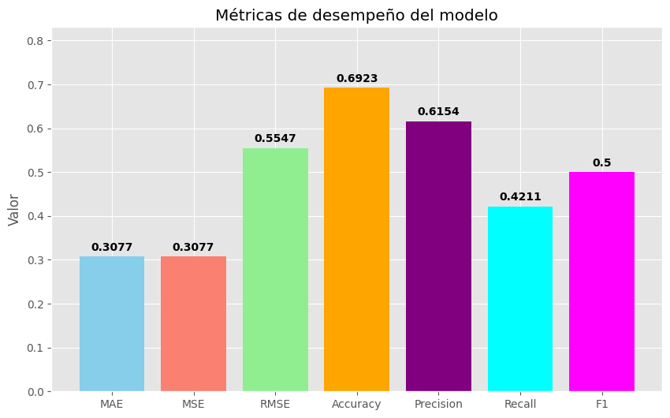

```
Confusion Matrix:
[[28  5]
 [11  8]]
TN: 28 FP: 5 FN: 11 TP: 8
```

```python
import matplotlib.pyplot as plt
from sklearn import metrics
from sklearn.metrics import accuracy_score, confusion_matrix, precision_score, recall_score, f1_score
import numpy as np

# ---- Calcular métricas ----
MAE = metrics.mean_absolute_error(y_test, y_pred)
MSE = metrics.mean_squared_error(y_test, y_pred)
RMSE = np.sqrt(metrics.mean_squared_error(y_test, y_pred))
accuracy = accuracy_score(y_test, y_pred)

precision = precision_score(y_test, y_pred)
recall = recall_score(y_test, y_pred)
f1 = f1_score(y_test, y_pred)

# ---- Mostrar métricas en consola ----
print('Mean Absolute Error (MAE):', round(MAE, 4))
print('Mean Squared Error (MSE):', round(MSE, 4))
print('Root Mean Squared Error (RMSE):', round(RMSE, 4))
print('Accuracy:', round(accuracy, 4))
print('Precision:', round(precision, 4))
print('Recall:', round(recall, 4))
print('F1:', round(f1, 4))

# ---- Crear diccionario con métricas para graficar ----
metricas = {
    'MAE': MAE,
    'MSE': MSE,
    'RMSE': RMSE,
    'Accuracy': accuracy,
    'Precision': precision,
    'Recall': recall,
    'F1': f1
}

# ---- Graficar ----
plt.figure(figsize=(10, 6))
colors = ['skyblue','salmon','lightgreen','orange','purple','cyan','magenta']
plt.bar(metricas.keys(), metricas.values(), color=colors)
plt.title('Métricas de desempeño del modelo')
plt.ylabel('Valor')
plt.ylim(0, 1.2*max(metricas.values()))  # escalar un poco arriba del máximo

# Mostrar valor exacto sobre cada barra
for i, v in enumerate(metricas.values()):
    plt.text(i, v + 0.02*max(metricas.values()), str(round(v,4)), ha='center', fontweight='bold')

plt.show()

# ---- Matriz de confusión ----
cm = confusion_matrix(y_test, y_pred)
print("Confusion Matrix:")
print(cm)
tn, fp, fn, tp = cm.ravel()
print("TN:", tn, "FP:", fp, "FN:", fn, "TP:", tp)
```

## Fase 3: Optimización del modelo de red neuronal (Fine Tuning)

**Estrategia de Optimización:**

**Paso 1. Parámetros de compilación: batch size, cantidad de epochs, optimizador.**

**Paso 2. Densidad de las capas de neuronas y regularización mediante Dropout.**

El Dropout permite “apagar” neuronas aleatoriamente durante el entrenamiento con el objetivo de evitar que el modelo dependa demasiado de ciertos patrones, reduciendo así el sobreajuste. El porcentaje de neuronas desactivadas se define con un valor entre 0 y 1 y su uso ayuda a que las redes aprendan de manera más generalizada. En otras palabras, en cada epoch solo una parte de las neuronas participa en el cálculo, lo que obliga a la red a distribuir mejor el aprendizaje. Para optimizar todos estos parámetros de forma sistemática, se puede utilizar la técnica GridSearchCV, que prueba múltiples combinaciones hasta encontrar la configuración más efectiva.

**Consideraciones sobre el tamaño del lote (Batch Size):**

- Un batch size grande ofrece gradientes más estables y un entrenamiento más rápido, pero consume más memoria y puede ser ineficiente en equipos locales.
- Un batch size pequeño usa menos memoria y puede adaptarse mejor a limitaciones de hardware, aunque hace que el entrenamiento sea más ruidoso y lento.

**Consideraciones sobre la densidad de neuronas:**

**Estrategia general:**

El proceso inicia seleccionando un batch size adecuado y luego ajustándolo según los recursos disponibles. Posteriormente, se prueban arquitecturas con diferentes cantidades de neuronas y niveles de Dropout. Este proceso suele ser iterativo, ya que la mejora del modelo implica evaluar constantemente los resultados obtenidos. En este caso, debido a que el accuracy, la precisión y el F1-score son relativamente bajos, el Fine Tuning es esencial para encontrar la arquitectura y configuración que permitan mejorar significativamente el rendimiento del modelo.

```
Accuracy en test: 0.6346
Precision: 0.5
Recall: 0.5789
F1: 0.5366
Matriz de confusión:
[[22 11]
 [ 8 11]]
```

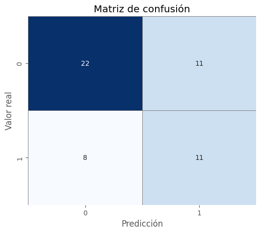

```python
import copy
import numpy as np
import matplotlib.pyplot as plt
from sklearn.model_selection import train_test_split
from sklearn.preprocessing import StandardScaler
from scikeras.wrappers import KerasClassifier
from tensorflow.keras.models import Sequential
from tensorflow.keras.layers import Dense
from sklearn.metrics import accuracy_score, confusion_matrix, precision_score, recall_score, f1_score

# --- Copiar los datos ---
X = copy.deepcopy(dataframe[categorical_binary_features + numeric_features])
Yval = Y.values

# --- Escalar solo las variables numéricas ---
scaler = StandardScaler()
X[numeric_features] = scaler.fit_transform(X[numeric_features])

# --- Dividir en train/test ---
X_train, X_test, y_train, y_test = train_test_split(X, Yval, test_size=0.2, random_state=0)

# --- Crear modelo simple ---
def build_model():
    model = Sequential()
    model.add(Dense(16, input_dim=X_train.shape[1], activation='relu'))
    model.add(Dense(1, activation='sigmoid'))
    model.compile(loss='binary_crossentropy', optimizer='rmsprop', metrics=['accuracy'])
    return model

# --- Envolver con KerasClassifier ---
estimator = KerasClassifier(build_fn=build_model, epochs=10, batch_size=50, verbose=0)

# --- Entrenar ---
estimator.fit(X_train, y_train)

# --- Predicciones ---
y_pred = estimator.predict(X_test)
y_pred = (y_pred > 0.5).astype(int).flatten()

# --- Métricas ---
accuracy = accuracy_score(y_test, y_pred)
precision = precision_score(y_test, y_pred)
recall = recall_score(y_test, y_pred)
f1 = f1_score(y_test, y_pred)

print("Accuracy en test:", round(accuracy,4))
print("Precision:", round(precision,4))
print("Recall:", round(recall,4))
print("F1:", round(f1,4))




# ---- Matriz de confusión ----
cm = confusion_matrix(y_test, y_pred)
print("Matriz de confusión:")
print(cm)
plt.figure(figsize=(6,5))
sns.heatmap(cm, annot=True, fmt='d', cmap='Blues', cbar=False, linewidths=0.5, linecolor='gray')
plt.xlabel('Predicción')
plt.ylabel('Valor real')
plt.title('Matriz de confusión')
plt.show()
```